# ITS_QC

Roger Calvas

2026-09-14

# Setear variables de ambiente

## Fijar la semilla

```r
# Se puede escoger cualquier numero
set.seed(9473)
```

## Tiempo de ejecucion

```r
# Cuando se empezo a correr el script?
start_time <- Sys.time()
start_time
```

```
## [1] "2026-09-14 14:48:54 UTC"
```

## Cargar librerias de R

```r
# Carga rápida con pacman
pacman::p_load(tidyverse, dada2, phyloseq, DT, devtools, patchwork, install = FALSE)
library( "ShortRead")
library("Biostrings")
```

# Objetivos del archivo:

1. Cargar los datos crudos a R.
2. Visualizar e inspeccionar la calidad.
3. Filtrar dependiendo de la calidad y quitar primers si fuera necesario.
4. Crear nuevos archivos con las secuencias que pasaron el filtro.
5. Inspeccionar la calidad de nuevo.
6. Calcular estadisticas relacionadas a medir el QC

## Inputs:

1. Fastq crudos sin adaptadores
2. Primers utilizados para amplificacion

## Outputs:

1. Plots de calidad pre y post filtro
2. Plots para inspeccionar la retencion
3. Fastq post QC con calidad post-filtro

# Cargar datos crudos

```r
# Fijar la ruta de los raw
raw_fastqs_path <- "data/its/01_DADA2/raw_fastq"

# Que archivos hay en la ruta?
head(list.files(raw_fastqs_path))
```

```
## [1] "ANF-004_1.fq.gz" "ANF-004_2.fq.gz" "ANF-006_1.fq.gz" "ANF-006_2.fq.gz"
## [5] "ANF-007_1.fq.gz" "ANF-007_2.fq.gz"
```

```r
# Cuantos archivos hay?
length(list.files(raw_fastqs_path))
```

```
## [1] 68
```

```r
# Crear un vector (conjunto del mismo tipo de dato) de las read forward (R1)
forward_reads <- list.files(raw_fastqs_path, pattern = "_1.fq.gz", full.names = TRUE)

# Chequeo de sanidad
stopifnot(length(forward_reads) < length(list.files(raw_fastqs_path)))

# Crear un vector de las reads reverse (R2)
reverse_reads <-list.files(raw_fastqs_path, pattern = "_2.fq.gz", full.names = TRUE)

# Chequeo de sanidad (ambas listas deberían ser del mismo tamaño)
stopifnot(length(reverse_reads) < length(list.files(raw_fastqs_path)))
stopifnot(length(reverse_reads) == length(forward_reads))
```

# Inspeccionar binning y primers

## Ver la distribucion de calidades

```r
# Leer el primer archivo FASTQ de las R1
fq_test <- readFastq(forward_reads[1])

# Extraer la matriz de calidades Phred
q_matrix <- as(quality(fq_test), "matrix")

# Imprimir en consola los valores únicos
bins_reales <- unique(as.vector(q_matrix))
sort(bins_reales)
```

```
## [1]  2 11 25 37
```

```r
# Anotar el output para el paso del modelo de errores
```

## Identificar e eliminar primers (Se puede saltar en su mayoria en 16s)

```r
# Crear variables con los primers utilizados en la secuenciacion
FWD <- "GCATCGATGAAGAACGCAGC"
REV <- "TCCTCCGCTTATTGATATGC"
# Transformarlos a DNA string para despues usar Biostrings
FWD_dna <- DNAString(FWD)
REV_dna <- DNAString(REV)

# Guardar las posibles direcciones del primer en un vector
FWD.orients <- sapply(
  c(Forward = FWD_dna,
    Complement =Biostrings::complement(FWD_dna),
    Reverse = Biostrings::reverse(FWD_dna),
    RevComp = Biostrings::reverseComplement(FWD_dna)),
  toString
)
REV.orients <- sapply(
  c(Forward = REV_dna,
    Complement =Biostrings::complement(REV_dna),
    Reverse = Biostrings::reverse(REV_dna),
    RevComp = Biostrings::reverseComplement(REV_dna)),
  toString
)

# Visualizar el vector
FWD.orients
```

```
##                Forward             Complement                Reverse
## "GCATCGATGAAGAACGCAGC" "CGTAGCTACTTCTTGCGTCG" "CGACGCAAGAAGTAGCTACG"
##                RevComp
## "GCTGCGTTCTTCATCGATGC"
```

```r
# Filtrar muestras con bases ambiguas (Ns) para mapear correctamente los primers
forward.filtN <- file.path("data/its/01_DADA2/filtN", basename(forward_reads))
reverse.filtN <- file.path("data/its/01_DADA2/filtN", basename(reverse_reads))

# Funcion de filtrado de DADA2
filterAndTrim(forward_reads, forward.filtN, reverse_reads, reverse.filtN, maxN = 0, multithread = TRUE)
```

```
## Creating output directory: data/its/01_DADA2/filtN
```

```r
## Función auxiliar para contar hits de primers en un archivo
primerHits <- function(primer, fn) {
    nhits <- vcountPattern(primer, sread(readFastq(fn)), fixed = FALSE)
    return(sum(nhits > 0))
}

# Contar los hits
rbind(
  FWD.ForwardReads = sapply(FWD.orients, primerHits, fn = forward.filtN[[1]]),
  FWD.ReverseReads = sapply(FWD.orients, primerHits, fn = reverse.filtN[[1]]),
  REV.ForwardReads = sapply(REV.orients, primerHits, fn = forward.filtN[[1]]),
  REV.ReverseReads = sapply(REV.orients, primerHits, fn = reverse.filtN[[1]])
)
```

```
##                  Forward Complement Reverse RevComp
## FWD.ForwardReads   74447          0       0       0
## FWD.ReverseReads       0          0       0   10736
## REV.ForwardReads       0          0       0   11726
## REV.ReverseReads   76652          0       0       0
```

```r
# Obtener a ruta de cutadapt al usar which cutadapt
cutadapt <- "/usr/bin/cutadapt"
# Comprobar que funciona cutadapt
system2(cutadapt, args = "--version")

# Preparar directorio para fastqs sin primers
path.cut <- file.path("data/its/01_DADA2/noPrimer_reads")
if(!dir.exists(path.cut)) dir.create(path.cut)
# Anadir los nombres de los archivos a la carpeta
forward_reads.cut <- file.path(path.cut, basename(forward_reads))
reverse_reads.cut <- file.path(path.cut, basename(reverse_reads))
# Reverse complement
FWD.RC <- dada2::rc(FWD)
REV.RC <- dada2::rc(REV)

# Filtrar el primer FWD y el complemente de REV de R1
R1.flags <- paste("-g", FWD, "-a", REV.RC)
# Filtrar el primer REV y el complemento de FWD de R2
R2.flags <- paste("-G", REV, "-A", FWD.RC)
# Correr cutadapt
for(i in seq_along(forward_reads)){
  system2(cutadapt, args = c(R1.flags, R2.flags, "-n", 2, "-m", 50,
                             "-o", forward_reads.cut[i], "-p", reverse_reads.cut[i], forward.filtN[i], reverse.filtN[i]), stdout = FALSE, stderr = FALSE)
}
```

## Buscar primers post corte

```r
# Buscar primers post procesamiento
rbind(
  FWD.ForwardReads = sapply(FWD.orients, primerHits, fn = forward_reads.cut),
  FWD.ReverseReads = sapply(FWD.orients, primerHits, fn = reverse_reads.cut),
  REV.ForwardReads = sapply(REV.orients, primerHits, fn = forward_reads.cut),
  REV.ReverseReads = sapply(REV.orients, primerHits, fn = reverse_reads.cut)
)
```

```
##                  Forward Complement Reverse RevComp
## FWD.ForwardReads       0          0       0       0
## FWD.ReverseReads       0          0       0      13
## REV.ForwardReads       0          0       0       0
## REV.ReverseReads     157          0       0       0
```

# Inspeccionar la calidad de las muestras pre filtrado

## Visualizar un subset de los datos para inferir la calidad

```r
# Seleccionar 12 muestras aleatorias
random_samples <- sample(1:length(reverse_reads.cut), size = 12)
random_samples
```

```
##  [1] 21 19 15 12 20 26  7 28 30 27 13  9
```

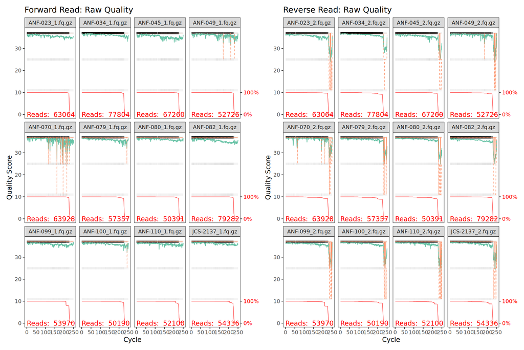

```r
# Calidad forward
forward_preQual_plot_12 <- plotQualityProfile(forward_reads.cut[random_samples]) +
  labs(title = "Forward Read: Raw Quality")

# Calidad reverse
reverse_preQual_plot_12 <- plotQualityProfile(reverse_reads.cut[random_samples]) +
  labs(title = "Reverse Read: Raw Quality")

# Unir los dos
forward_preQual_plot_12 + reverse_preQual_plot_12
```

## Plot de calidad de todas las secuencias agregadas

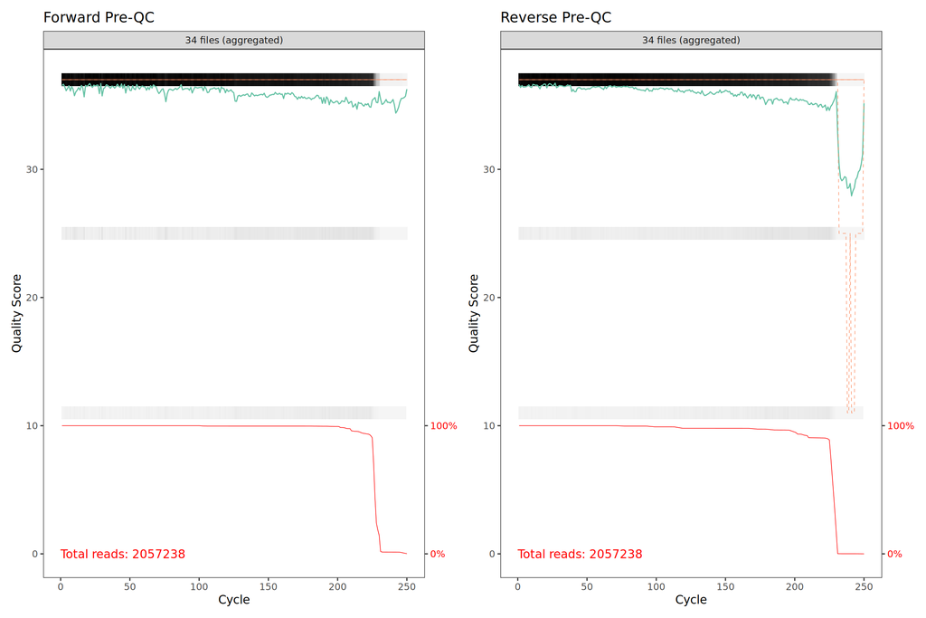

```r
# Reads forward
forward_preQC_plot <-
  plotQualityProfile(forward_reads.cut, aggregate = TRUE) +
  labs(title = "Forward Pre-QC")

# Reads reverse
reverse_preQC_plot <-
  plotQualityProfile(reverse_reads.cut, aggregate = TRUE) +
  labs(title = "Reverse Pre-QC")

# Juntar los plots en una sola figura
preQC_aggregate_plot <-
  forward_preQC_plot + reverse_preQC_plot
# Mostrar la figura
preQC_aggregate_plot
```

## Tenemos datos binned?

```r
# Sacamos la primera muestras de la lista para probar con la calidad de sus reads
fq_test <- readFastq(forward_reads[1])

# Lo guardamos como matrix para aplicar unique
q_matrix <- as(quality(fq_test), "matrix")

# Obtenemos los valores unicos de calidad
bins_reales <- na.omit(unique(as.vector(q_matrix)))

# Mostrarlos
sort(bins_reales)
```

```
## [1]  2 11 25 37
```

Pregunta 1: Que inferencias iniciales en relacion al filtrado se pueden encontrar hasta ahora?

[*Calidad alta de inicio a ~200pb:*  
Se mantiene la tendendencia de illumina de perdida de calidad en las lecturas finales de R2 pero en contraste de lo esperado no hay un drop de calidad inicial muy fuerte, puede ser que haya sido enmascarado por el binning.  
- **solucion:** Ya que no se puede usar trimLeft o truncLen por la naturaleza de largo variable en ITS, se puede usar maxEE asimetricos tal vez (2,3) porque tampoco quisiera filtrar demasiado amplicones largos (por tener mas pb es mas probable que tengan EE altos)  
*Calidad en binning:* al tener valores discretos se podria ver como cambian los largos y la profundidad al hacer truncq 11 y truncq 2, pero esto podria dejar secuencias demasiado pequeñas que no empalmaran - **solucion:** minLen de 50 para evitar cortar todas las lecturas largas y probar la distribucion entre truncq 11 y 2]

# Filter and trim

## Preparar donde se van a guardar las reads filtradas

```r
# Crear un vector del nombre de las muestras
sample_names <- sapply(strsplit(basename(forward_reads.cut), "_"), `[`,1)

# Como se ven los nombres de las muestras?
head(sample_names)
```

```
## [1] "ANF-004" "ANF-006" "ANF-007" "ANF-011" "ANF-018" "ANF-021"
```

```r
# Definir el path de las muestras post filtro
filtered_path <- "data/its/01_DADA2/filtered_fastqs"

# Crear el directorio si no existe
if(!dir.exists(filtered_path)) dir.create(filtered_path, recursive = TRUE)

# Crear un vector para R1 post filtro
filtered_forward_reads <-
  file.path(filtered_path, paste0(sample_names, "_R1_filtered.fastq.gz"))

# Intuition Check
length(filtered_forward_reads)
```

```
## [1] 34
```

```r
# Vector para R2
filtered_reverse_reads <-
  file.path(filtered_path, paste0(sample_names, "_R2_filtered.fastq.gz"))

# Intuition Check
head(filtered_reverse_reads)
```

```
## [1] "data/its/01_DADA2/filtered_fastqs/ANF-004_R2_filtered.fastq.gz"
## [2] "data/its/01_DADA2/filtered_fastqs/ANF-006_R2_filtered.fastq.gz"
## [3] "data/its/01_DADA2/filtered_fastqs/ANF-007_R2_filtered.fastq.gz"
## [4] "data/its/01_DADA2/filtered_fastqs/ANF-011_R2_filtered.fastq.gz"
## [5] "data/its/01_DADA2/filtered_fastqs/ANF-018_R2_filtered.fastq.gz"
## [6] "data/its/01_DADA2/filtered_fastqs/ANF-021_R2_filtered.fastq.gz"
```

## Filtrar secuencias

```r
filtered_reads <-
  filterAndTrim(fwd = forward_reads.cut, filt = filtered_forward_reads,
              rev = reverse_reads.cut, filt.rev = filtered_reverse_reads,
              maxN = 0, maxEE = c(2,3),
              truncQ = 2,
              minLen = 50,
              rm.phix = TRUE, compress = TRUE,
              multithread = 10)
```

# Inspeccionar la calidad post-filtrado

## Calidad de 12 muestras postQC

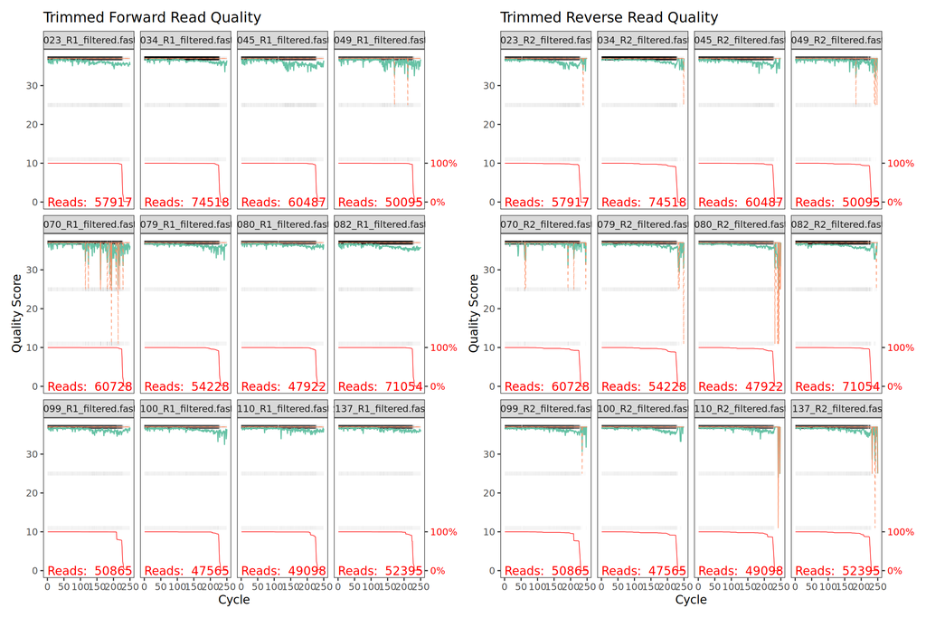

```r
# Se usan las mismas muestras, figura forward
forward_filteredQual_plot_12 <-
  plotQualityProfile(filtered_forward_reads[random_samples]) +
  labs(title = "Trimmed Forward Read Quality")

# Figura reversed
reverse_filteredQual_plot_12 <-
  plotQualityProfile(filtered_reverse_reads[random_samples]) +
  labs(title = "Trimmed Reverse Read Quality")

# unir los plots
forward_filteredQual_plot_12 + reverse_filteredQual_plot_12
```

## Calidad de las secuencias agregadas postQC

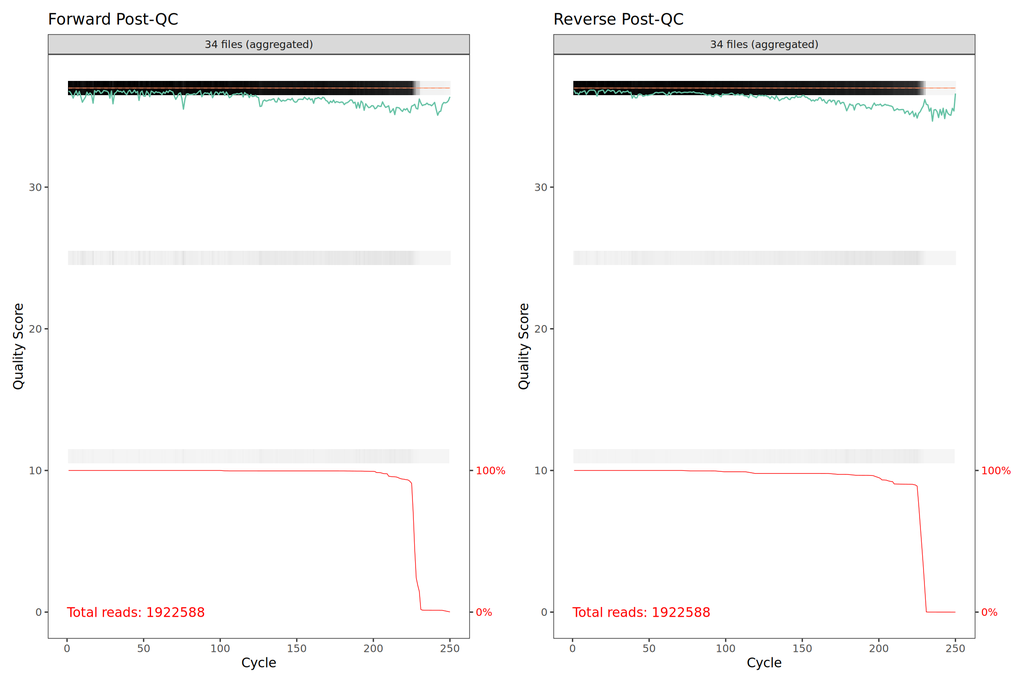

```r
# reads forward
forward_postQC_plot <-
  plotQualityProfile(filtered_forward_reads, aggregate = TRUE) +
  labs(title = "Forward Post-QC")

# reads reverse
reverse_postQC_plot <-
  plotQualityProfile(filtered_reverse_reads, aggregate = TRUE) +
  labs(title = "Reverse Post-QC")

# Juntar los plots en una sola figura
postQC_aggregate_plot <-
  forward_postQC_plot + reverse_postQC_plot
# Mostrar la figura
postQC_aggregate_plot
```

## Ver las diferencias en una misma figura

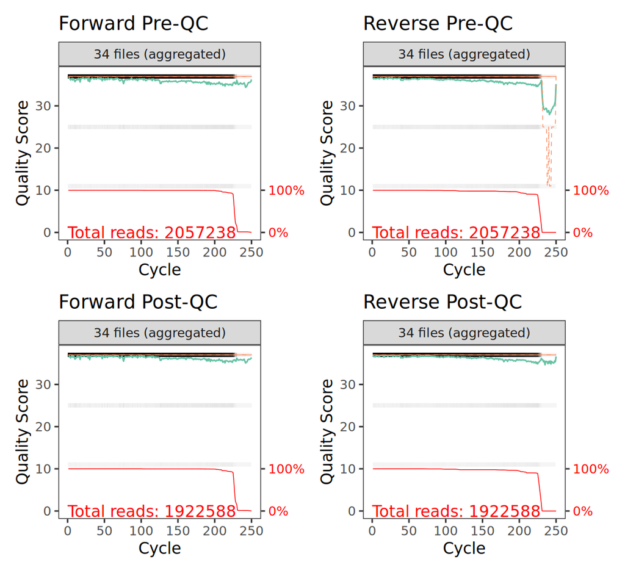

```r
# Plot the pre and post together in one plot
preQC_aggregate_plot / postQC_aggregate_plot
```

# Inspeccionar la retencion

## Guardar el output en un data frame

```r
filtered_df <- as.data.frame(filtered_reads) %>%
  mutate(percent.retained = reads.out/reads.in)

# Visualizar la tabla
DT::datatable(filtered_df)
```

|  | reads.in | reads.out | percent.retained |
| --- | --- | --- | --- |
| ANF-004_1.fq.gz | 77389 | 73782 | 0.9533913088423419 |
| ANF-006_1.fq.gz | 77466 | 72925 | 0.9413807347739653 |
| ANF-007_1.fq.gz | 52184 | 47866 | 0.917254330829373 |
| ANF-011_1.fq.gz | 73803 | 59592 | 0.8074468517539938 |
| ANF-018_1.fq.gz | 52769 | 50036 | 0.9482082283158673 |
| ANF-021_1.fq.gz | 62599 | 59449 | 0.9496797073435678 |
| ANF-023_1.fq.gz | 63064 | 57917 | 0.918384498287454 |
| ANF-026_1.fq.gz | 54988 | 51600 | 0.9383865570669965 |
| ANF-034_1.fq.gz | 77804 | 74518 | 0.9577656675749319 |
| ANF-042_1.fq.gz | 49789 | 47780 | 0.9596497218261062 |

[output cut: 24 more lines]

## Calcular estadisticas de filtrado

```r
read_stats_df <-
  filtered_df %>%
  reframe(median_reads_in = median(reads.in),
          median_reads_out = median(reads.out),
          median_percent_retained = (median(reads.out)/median(reads.in)),
          max_percent_retained = max(reads.out/reads.in),
          min_percent_retained = min(reads.out/reads.in))

# Imprime la tabla!
read_stats_df
```

```
##   median_reads_in median_reads_out median_percent_retained max_percent_retained
## 1           54662          51997.5                0.951255            0.9649681
##   min_percent_retained
## 1            0.8074469
```

## Grafico de estadisticas

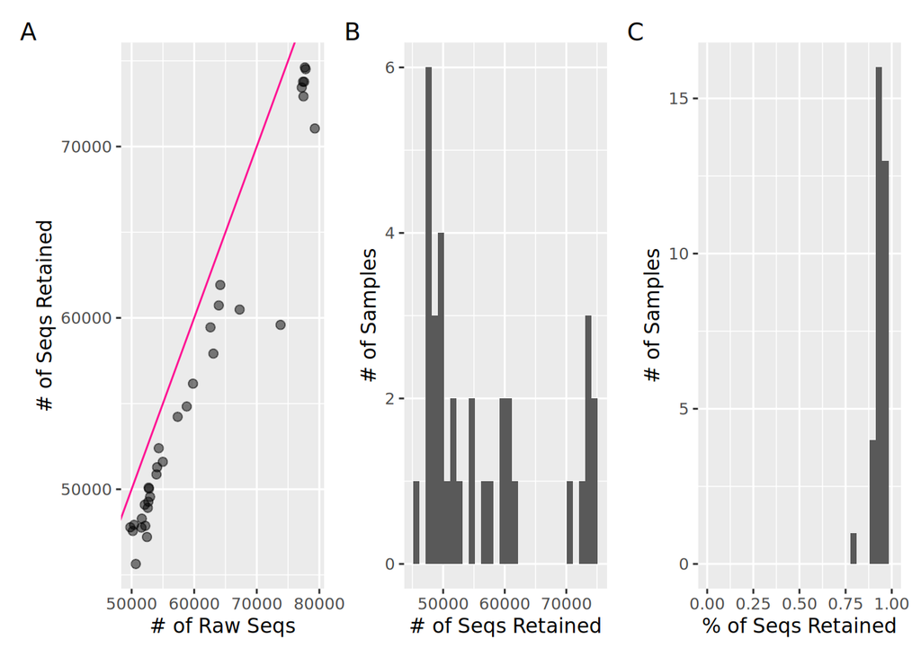

```r
numSeqs_QC_dotplot <-
  filtered_df %>%
  ggplot(aes(x = reads.in, y = reads.out)) +
  geom_point(alpha = 0.5, size = 2) +
  labs(x = "# of Raw Seqs",
       y = "# of Seqs Retained") +
  # Now let's add a 1:1 line for reference of keeping 100% of the reads
  geom_abline(slope=1, intercept = 0, color = "deeppink")

# Now, let's look at the number of reads retained in a histogram
numRetained_QC_histplot <-
  filtered_df %>%
  ggplot(aes(x = reads.out)) +
  geom_histogram() +
  labs(x = "# of Seqs Retained",
       y = "# of Samples")

# Create a histogram of percent reads retained in a histogram
percSeqs_QC_histplot <-
  filtered_df %>%
  ggplot(aes(x = percent.retained)) +
  geom_histogram() +
  labs(x = "% of Seqs Retained",
       y = "# of Samples") +
  # Set the scale to be between 0-1 (0-100%)
  scale_x_continuous(limits = c(0, 1))

# Now, let's put the plots together
numSeqs_QC_dotplot + numRetained_QC_histplot + percSeqs_QC_histplot +
  plot_annotation(tag_levels = 'A')
```

Pregunta 2: Explica por que usaste los parametros finales para filter and trim y como se ve la calidad post filtrado. [La calidad se ve mas solida despues del filtrado, los dips finales en las muestras R2 se han reducido pero no eliminado por completo, solo que: truncq = 11 reduce demasiado el numero de muestras con largo alto y maxEE= c(1,1) elimina tambien muestras largas de sobremanera, viendo los graficos corriendo diferentes filter and trim creo que el actual es el mejor punto medio]

# Stats del script

## Tiempo final

```r
# Tiempo al terminar el script
end_time <- Sys.time()
end_time
```

```
## [1] "2026-09-14 14:56:28 UTC"
```

## Tiempo de corrida

```r
elapsed_time <- round((end_time - start_time), 3)
elapsed_time
```

```
## Time difference of 7.564 mins
```